# More Classification: ISL 4

DJM

3 April 2018

# Linear classifiers

## Logistic regression

- Logistic regression is one example of a linear classifier.
- It produces a line (or plane or hyperplane) which separates the two classes.

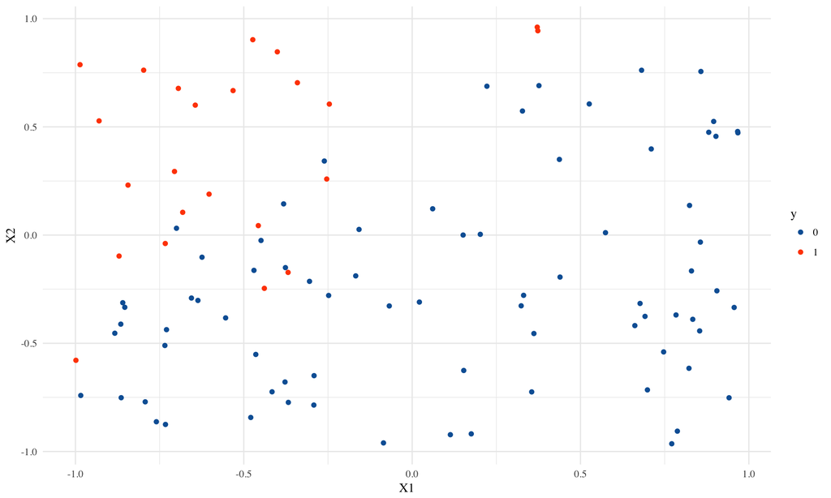

```r
g <- ggplot(df, aes(X1,X2,color=y)) + geom_point() +
  scale_color_manual(values=c(blue,red))
g
```

```r
log.lm = glm(y~.,data=df, family='binomial')
summary(log.lm)
```

```
##
## Call:
## glm(formula = y ~ ., family = "binomial", data = df)
##
## Deviance Residuals:
##      Min        1Q    Median        3Q       Max
## -1.63909  -0.24256  -0.03246  -0.00061   2.35104
##
## Coefficients:
##             Estimate Std. Error z value Pr(>|z|)
## (Intercept)   -3.803      1.010  -3.764 0.000167 ***
## X1            -6.593      1.918  -3.438 0.000586 ***
## X2             7.271      1.945   3.739 0.000185 ***
## ---
## Signif. codes:  0 '***' 0.001 '**' 0.01 '*' 0.05 '.' 0.1 ' ' 1
##
## (Dispersion parameter for binomial family taken to be 1)
##
##     Null deviance: 107.855  on 99  degrees of freedom
## Residual deviance:  36.785  on 97  degrees of freedom
## AIC: 42.785
##
## Number of Fisher Scoring iterations: 8
```

## What is the line?

- Suppose we decide “Predict `1` if `predict(log.lm) > 0.5`”.
- This means “For which combinations of `x1` and `x2` is
  $$\frac{\exp\left(\widehat{\beta}_0 + \widehat{\beta}_1 x_1 + \widehat{\beta}_2 x_2\right)}
  {1+\exp\left(\widehat{\beta}_0 + \widehat{\beta}_1 x_1 + \widehat{\beta}_2 x_2\right)} > 0.5 ?$$
- Solving this gives
  $$\widehat{\beta}_0 + \widehat{\beta}_1 x_1 + \widehat{\beta}_2 x_2 > \log(.5)-\log(1-.5)
  \Rightarrow x2 > -\frac{\widehat{\beta}_0 + \widehat{\beta}_1 x_1}{\widehat{\beta}_2}.$$
- That’s just a line. Let’s plot it:

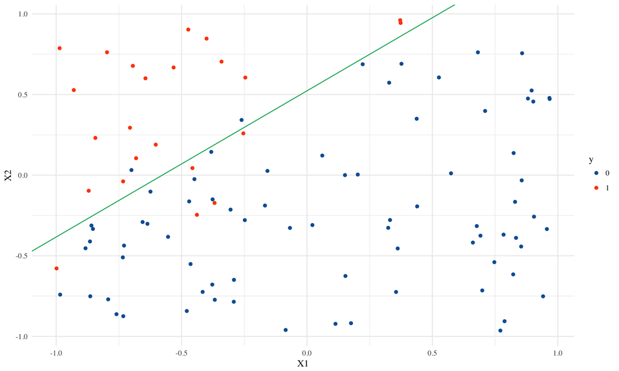

```r
cc = coefficients(log.lm)
g + geom_abline(intercept = -cc[1]/cc[3], slope = -cc[2]/cc[3], color=green)
```

## Classification boundary

- We call that line the “classification boundary”
- The `ilogit` function looks like a ramp:

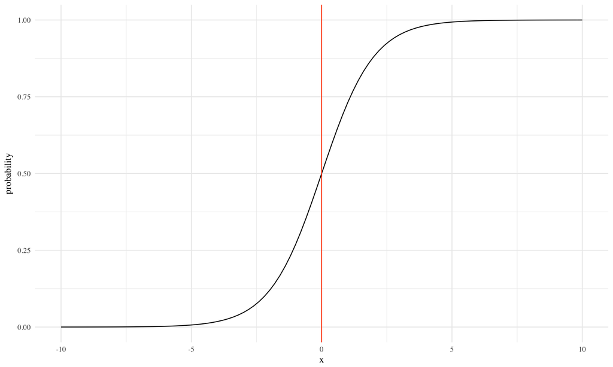

```r
ggplot(data.frame(x=c(-10,10)), aes(x)) + stat_function(fun=ilogit) +
  geom_vline(xintercept = 0, color=red) + ylab('probability')
```

- Again, solving for where the equation crosses 0.5, gives us a “line”.
- Logistic regression always produces “linear” classification boundaries, so we call it a “linear classifier”

## Lots of different boundaries

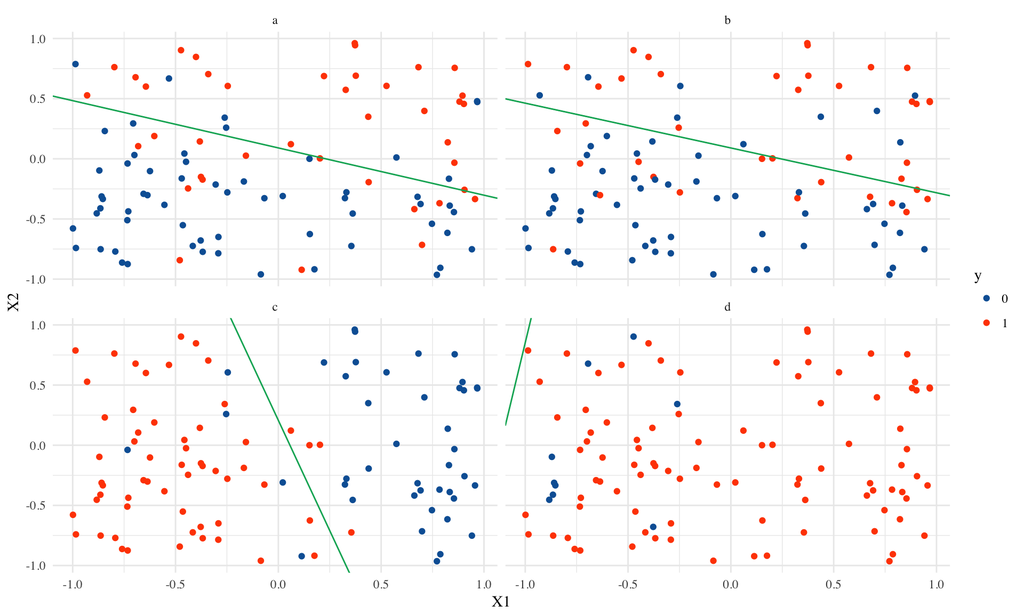

```
## # A tibble: 4 x 3
## # Groups: index [4]
##   index intercept  slope
##   <chr>     <dbl>  <dbl>
## 1 a        0.0907 -0.393
## 2 b        0.0905 -0.373
## 3 c        0.207  -3.67
## 4 d        7.96    7.11
```

# Linear discriminant analysis

## LDA

(Not to be confused with Latent Dirichlet Allocation, also abbrev. LDA)

- Suppose $X_i {\ \vert\ }Y_i=1 \sim N(\mu_1, \Sigma)$
- And $X_i {\ \vert\ }Y_i=0 \sim N(\mu_0, \Sigma)$
- Note that these share $\Sigma$.
- Suppose that $P(Y_i=1)=\pi_1$

Bayes Rule:
$$P(Y_i=1 {\ \vert\ }X_i=x) = \frac{P(X_i {\ \vert\ }Y_i=1)\pi_1}
{P(X_i {\ \vert\ }Y_i=1)\pi_1 + P(X_i {\ \vert\ }Y_i=0)\pi_0}$$

- So if we know $\pi_1, \mu_1, \mu_0, \Sigma$, then we can find $P(Y_i=1{\ \vert\ }X)$

## Simplification

$$\begin{aligned}
\frac{P(X_i {\ \vert\ }Y_i=1)\pi_1}
{P(X_i {\ \vert\ }Y_i=1)\pi_1 + P(X_i {\ \vert\ }Y_i=0)\pi_0}
&= \frac{\pi_1 \frac{1}{(2\pi|\Sigma|)^{p/2}}\exp\left(-\frac{1}{2}(x-\mu_1)^\top
\Sigma^{-1} (x-\mu_1) \right)}
{\sum_{j=0,1}\pi_j\frac{1}{(2\pi|\Sigma|)^{p/2}}\exp\left(-\frac{1}{2}(x-\mu_j)^\top
\Sigma^{-1} (x-\mu_j) \right)}\\
&= (\textrm{take logs})\\
&= \ldots\\
&=x^\top\Sigma^{-1}\mu_1-\frac{1}{2}\mu_1^\top \Sigma^{-1}\mu_1 + \log\pi_1\\
&=: \delta_1
\end{aligned}$$

- If this is bigger than $\delta_0$, we predict 1 else 0.

## Why is this linear?

- We are indifferent when $\delta_1=\delta_0$

$$\begin{aligned}
&\delta_1=\delta_0\\
&\Rightarrow x^\top\Sigma^{-1}\mu_1-\frac{1}{2}\mu_1^\top \Sigma^{-1}\mu_1 + \log\pi_1 =
x^\top\Sigma^{-1}\mu_0-\frac{1}{2}\mu_0^\top \Sigma^{-1}\mu_0 + \log\pi_0\\
&\Rightarrow x^\top\Sigma^{-1}(\mu_1-\mu_0) -\frac{1}{2}\left(\mu_1^\top \Sigma^{-1}\mu_1 -
\mu_0^\top \Sigma^{-1}\mu_0\right) + \log\pi_1-\log\pi_0 = 0
\end{aligned}$$

## Example

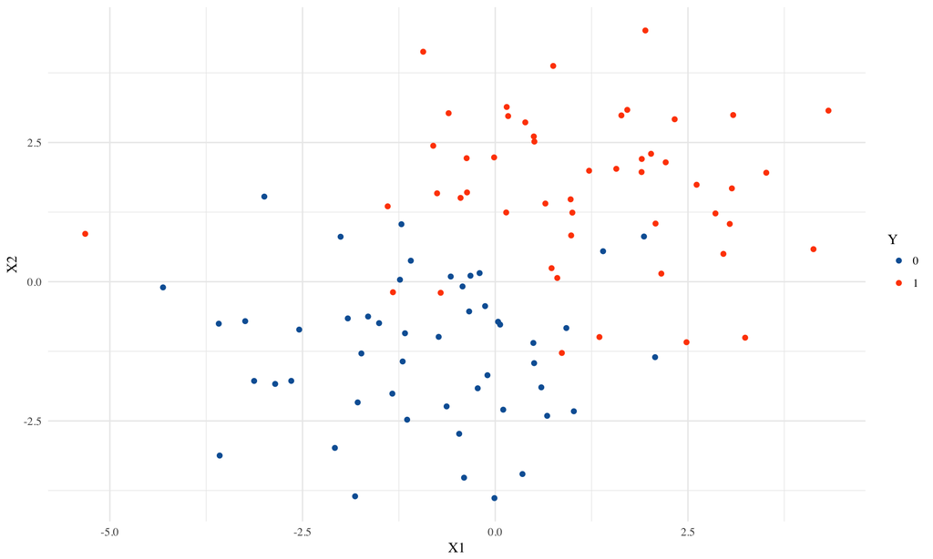

```r
library(mvtnorm)
n = 100
pi1 = 0.5
n1 = floor(n*pi1); n0 = n-n1
mu1 = c(1,2); mu0 = c(-1,-1)
Sigma = 2*diag(2)
X1 = rmvnorm(n1, mu1, Sigma)
X2 = rmvnorm(n0, mu0, Sigma)
X = rbind(X1,X2)
Y = factor(c(rep(1,n1),rep(0,n0)))
df = data.frame(Y,X)
g <- ggplot(df, aes(X1,X2,color=Y)) + geom_point() + scale_color_manual(values=c(blue,red))
g
```

## The distributions and the classifier

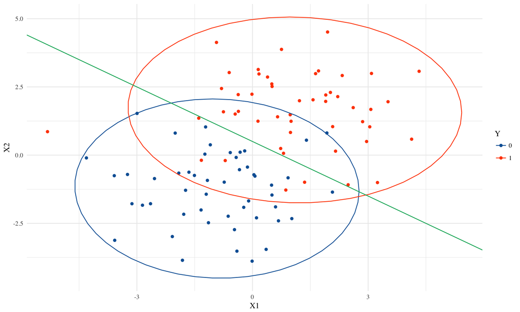

```r
Sinv = solve(Sigma)
slope.vec = t(mu1-mu0) %*% Sinv
intercept = 0.5*(t(mu0) %*% Sinv %*% mu0 - t(mu1) %*% Sinv %*% mu1)
g + stat_ellipse(type='norm') + # these are estimated, not the truth
  geom_abline(intercept = -intercept/slope.vec[2],
              slope = -slope.vec[1]/slope.vec[2], color=green)
```

## Try another one

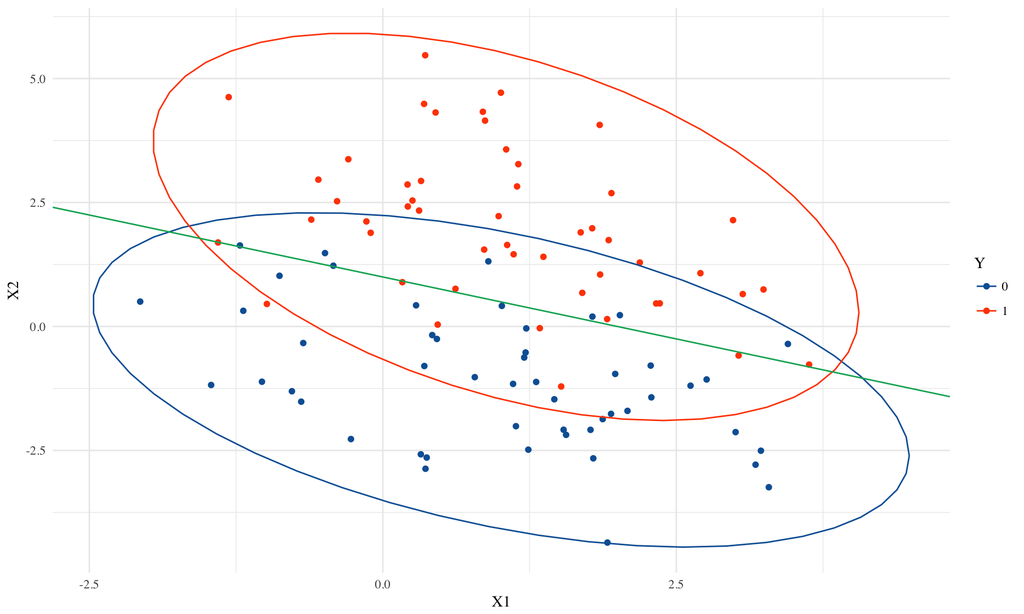

```r
mu1 = c(1,2); mu0 = c(1,-1)
Sigma = 2*matrix(c(1,-.5,-.5,1),2)
X1 = rmvnorm(n1, mu1, Sigma)
X2 = rmvnorm(n0, mu0, Sigma)
X = rbind(X1,X2)
Y = factor(c(rep(1,n1),rep(0,n0)))
df = data.frame(Y,X)
Sinv = solve(Sigma)
slope.vec = t(mu1-mu0) %*% Sinv
intercept = 0.5*(t(mu0) %*% Sinv %*% mu0 - t(mu1) %*% Sinv %*% mu1)
ggplot(df, aes(X1,X2,color=Y)) + geom_point() + scale_color_manual(values=c(blue,red)) +
  stat_ellipse(type='norm') +
  geom_abline(intercept = -intercept/slope.vec[2],
              slope = -slope.vec[1]/slope.vec[2], color=green)
```

- Note: here there is a single $\Sigma$, but I don’t know how to plot ellipses in `ggplot`. So these are estimated.

## Same one, but make n big

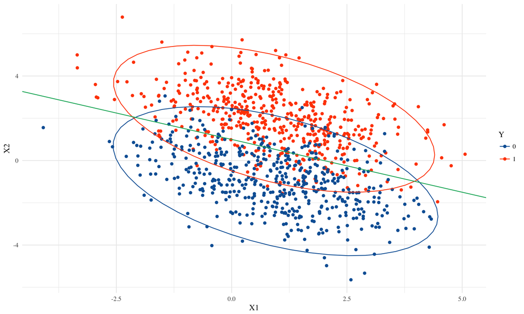

```r
n1=500; n0=500
X1 = rmvnorm(n1, mu1, Sigma)
X2 = rmvnorm(n0, mu0, Sigma)
X = rbind(X1,X2)
Y = factor(c(rep(1,n1),rep(0,n0)))
df = data.frame(Y,X)
Sinv = solve(Sigma)
slope.vec = t(mu1-mu0) %*% Sinv
intercept = 0.5*(t(mu0) %*% Sinv %*% mu0 - t(mu1) %*% Sinv %*% mu1)
ggplot(df, aes(X1,X2,color=Y)) + geom_point() + scale_color_manual(values=c(blue,red)) +
  stat_ellipse(type='norm') +
  geom_abline(intercept = -intercept/slope.vec[2],
              slope = -slope.vec[1]/slope.vec[2], color=green)
```

## Same one, but change P(Y=1)

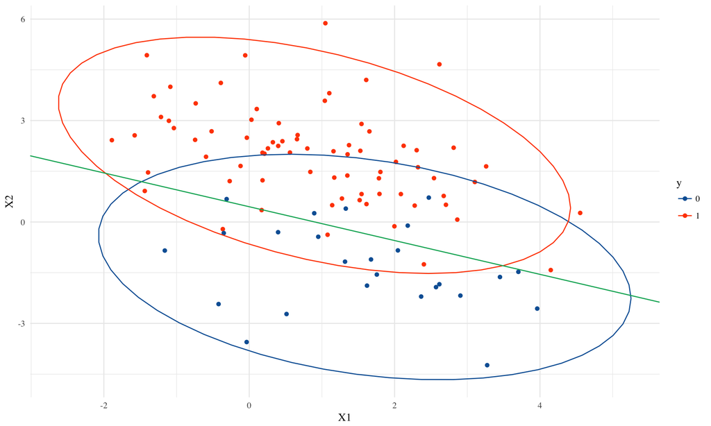

```r
n1=75; n0=25
X1 = rmvnorm(n1, mu1, Sigma)
X2 = rmvnorm(n0, mu0, Sigma)
X = rbind(X1,X2)
y = factor(c(rep(1,n1),rep(0,n0)))
df = data.frame(y,X)
Sinv = solve(Sigma)
slope.vec = t(mu1-mu0) %*% Sinv
intercept = 0.5*(t(mu0) %*% Sinv %*% mu0 - t(mu1) %*% Sinv %*% mu1) + log(.75) - log(.25)
ggplot(df, aes(X1,X2,color=y)) + geom_point() + scale_color_manual(values=c(blue,red)) +
  stat_ellipse(type='norm') +
  geom_abline(intercept = -intercept/slope.vec[2],
              slope = -slope.vec[1]/slope.vec[2], color=green)
```

## Ok, how do you do it?

- Estimate everything with sample analogues
- $\widehat{\pi}_1 = n_1/(n_1+n_0)$
- $\widehat{\mu}_1 = \frac{1}{n_1}\sum X_i I(Y_i=1)$. Same for $\widehat{\mu}_0$.
- $\widehat{\Sigma} = \frac{1}{n}\sum_{ij} I(Y_i=j)(X_i-\widehat{\mu}_j)^\top(X_i-\widehat{\mu}_j)$

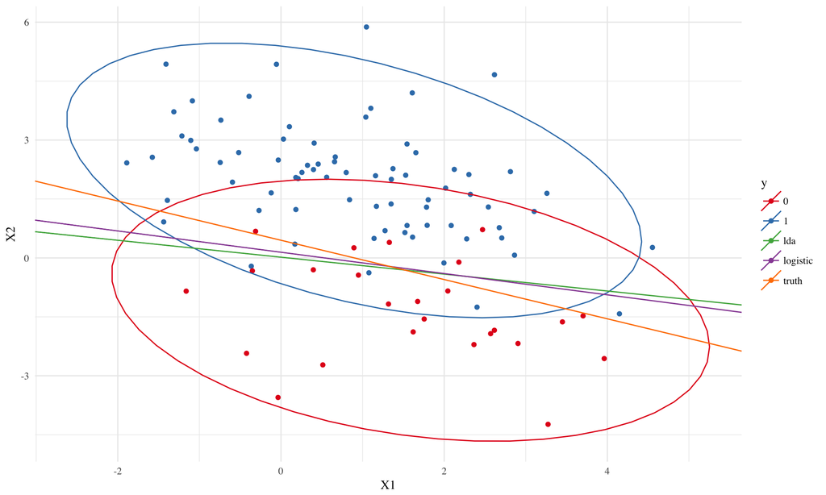

```r
library(MASS)
lda.fit = lda(y~X1+X2, data=df)
sl.int = lda.disc(lda.fit,df)
log.bd = decision.boundary(df)
truth = data.frame(intercept=-intercept/slope.vec[2], slope=-slope.vec[1]/slope.vec[2])
dfa = rbind(sl.int,log.bd,truth)
dfa$discriminant = c('lda','logistic','truth')
ggplot(df, aes(X1,X2,color=y)) + geom_point() + scale_color_brewer(palette = 'Set1')+
  stat_ellipse(type='norm') +
  geom_abline(mapping=aes(intercept=intercept, slope=slope,color=discriminant),data=dfa)
```

## Comparing LDA and Logistic regression

- Both are linear in $x$:
  - LDA$\longrightarrow \alpha_0 + \alpha_1^\top x$
  - Logit$\longrightarrow \beta_0 + \beta_1^\top x$.
- But the parameters are estimated differently.
- Examine the joint distribution of $(X,y)$:
  - LDA $\prod_i f(x_i,y_i) = \underbrace{\prod_i f(X_i | y_i)}_{\textrm{Gaussian}}\underbrace{\prod_i f(y_i)}_{\textrm{Bernoulli}}$
  - Logistic $\prod_i f(x_i,y_i) = \underbrace{\prod_i f(y_i | X_i)}_{\textrm{Logistic}}\underbrace{\prod_i f(X_i)}_{\textrm{Ignored}}$
- LDA estimates the joint, but Logistic estimates only the conditional distribution. But this is really all we need.
- So logistic requires fewer assumptions.
- But if the two classes are perfectly separable, logistic crashes (and the MLE is undefined)
- LDA works even if the conditional isn’t normal, but works poorly if any X is qualitative

## QDA

- Start like LDA, but let $\Sigma_1 \neq \Sigma_0$.
- This gives a “quadratic” decision boundary (it’s a curve).
- If we have many columns in $X$ ($p$)
  - Logistic estimates $p+1$ parameters
  - LDA estimates $2p + p(p+1)/2 + 1$
  - QDA estimates $2p + p(p+1) + 1$
- If $p=50$,
  - Logistic: 51
  - LDA: 1376
  - QDA: 2651
- QDA doesn’t get used much: there are better nonlinear versions with way “fewer” parameters (SVMs)
- LDA only really depends on $\Sigma^{-1}(\mu_1-\mu_0)$ and $(\mu_1+\mu_0)$, so it has $<2p$ parameters.

# KNN

## Re-entry

- We saw $k$-nearest neighbors at the very beginning of the course.

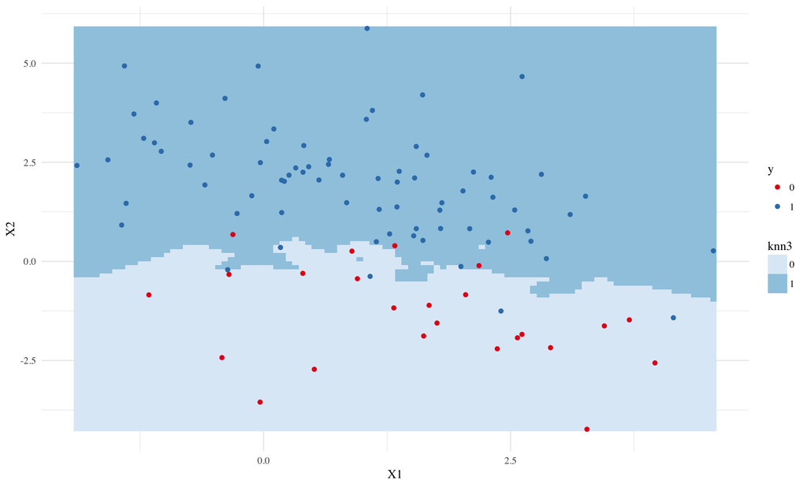

```r
library(class)
pred.grid = expand.grid(X1=seq(min(df$X1),max(df$X1),len=100),
                        X2=seq(min(df$X2),max(df$X2),len=100))
pred.grid$knn3 = knn(df[,-1], pred.grid, df$y, k=3)
ggplot(pred.grid, aes(X1,X2)) + geom_raster(aes(fill=knn3)) +
  scale_fill_brewer() + geom_point(data=df,mapping=aes(X1,X2,color=y)) +
                        scale_color_brewer(palette = 'Set1')
```

## Choosing k

- Choosing $k$ is very important.

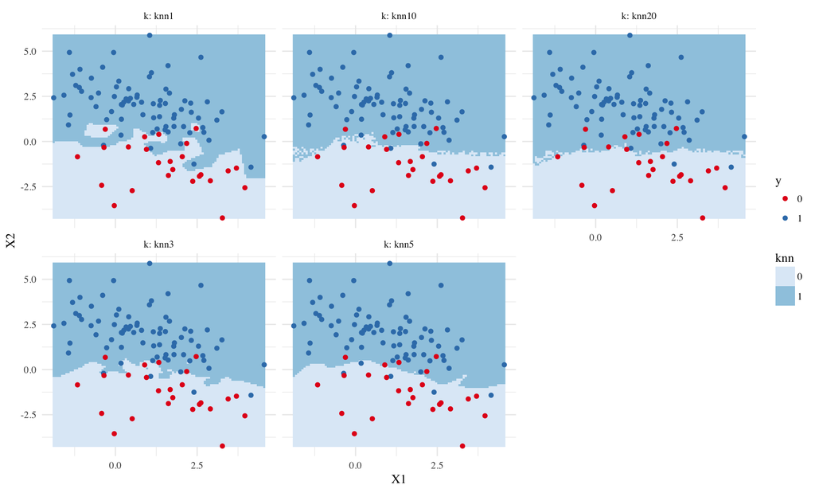

```r
pred.grid$knn1 = knn(df[,-1], pred.grid[,1:2], df$y, k=1)
pred.grid$knn5 = knn(df[,-1], pred.grid[,1:2], df$y, k=5)
pred.grid$knn10 = knn(df[,-1], pred.grid[,1:2], df$y, k=10)
pred.grid$knn20 = knn(df[,-1], pred.grid[,1:2], df$y, k=20)
pg = gather(pred.grid,key='k',value='knn',-c(X1,X2))

ggplot(pg, aes(X1,X2)) + geom_raster(aes(fill=knn)) +
  facet_wrap(~k,labeller = label_both) + scale_fill_brewer()+
  geom_point(data=df,mapping=aes(X1,X2,color=y)) +
  scale_color_brewer(palette = 'Set1')
```

- How should we choose $k$?
- Scaling is also very important. The nearest neighbors are determined by their distance, so better to standardize your data first.

## `knn.cv`

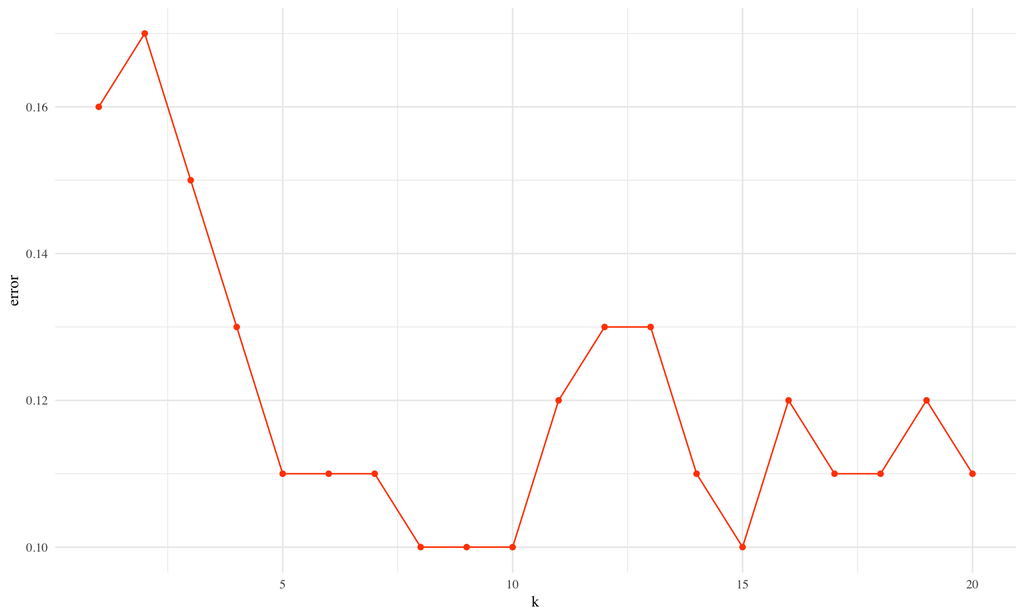

```r
kmax = 20
err = double(kmax)
for(ii in 1:kmax){
  pk = knn.cv(df[,-1],df$y, k=ii) # does leave one out CV
  err[ii] = mean(pk != df$y)
}
ggplot(data.frame(k=1:kmax,error=err), aes(k,error)) + geom_point(color=red) +
  geom_line(color=red)
```

- I would use the largest `k` that is close to the minimum. This produces simpler, smoother, decision boundaries.

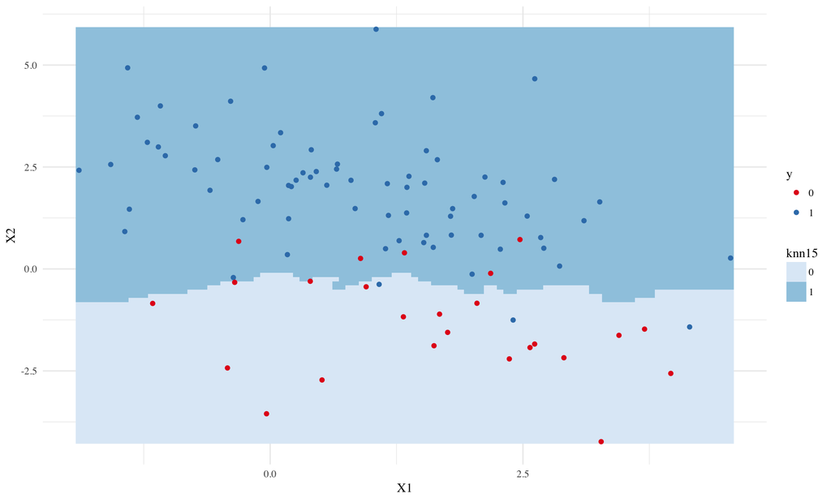

```r
pred.grid$knn15 = knn(df[,-1], pred.grid[,1:2], df$y, k=15)
ggplot(pred.grid, aes(X1,X2)) + geom_raster(aes(fill=knn15)) +
  scale_fill_brewer() + geom_point(data=df,mapping=aes(X1,X2,color=y)) +
                        scale_color_brewer(palette = 'Set1')
```

```r
(tt <- table(knn(df[,-1],df[,-1],df$y,k=15),df$y,dnn=c('predicted','truth')))
```

```
##          truth
## predicted  0  1
##         0 20  3
##         1  5 72
```

```r
1-sum(diag(tt))/sum(tt)
```

```
## [1] 0.08
```

# Kernelization

## Other non-linear classifiers

- We already saw that knn produces non-linear decision boundaries.
- Next week, we’ll see trees, which are also non-linear.
- “Kernelization” is a way of turning linear classifiers (or linear regression) into non-linear classifiers.
- You’ve already seen this happen when you add interactions or quadratic terms to linear models

## The idea

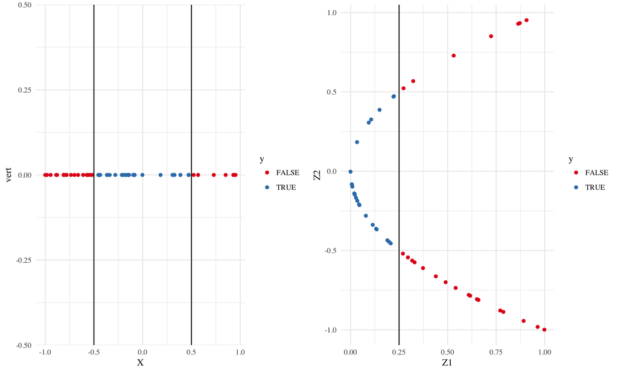

- A linear classifier in the higher-dimensional space corresponds to a non-linear classifier in low dimensions.
- Of course, if dim$(\mathcal{Z})$ is too big, then there will be too many parameters to estimate well.

## The trick

If:

1. There is a mapping $\phi: \mathcal{X}\rightarrow\mathcal{Z}$
2. Your classifiers of choice only needs the inner product between observations, not the observations themselves. (logistic regression, LDA, and SVMs work)
3. There is a function $K$ such that $K(x,x')=\langle\phi(x),\phi(x')\rangle$ (Mercer’s theorem gives this)

Then, we can just replace all inner products $\langle x,x'\rangle$ with $K(x,x')$.

- This produces a nonlinear classifier based on a linear classifier.
- We don’t actually need $x$ or $\phi$, just $K(x,x')$ (this is an $n\times n$ matrix)
- $\mathcal{Z}$ can be infinite dimensional.

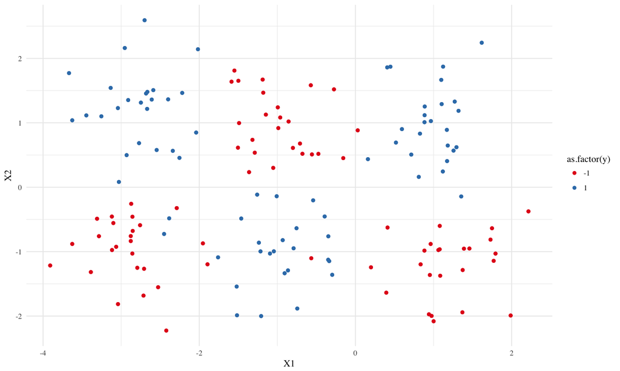

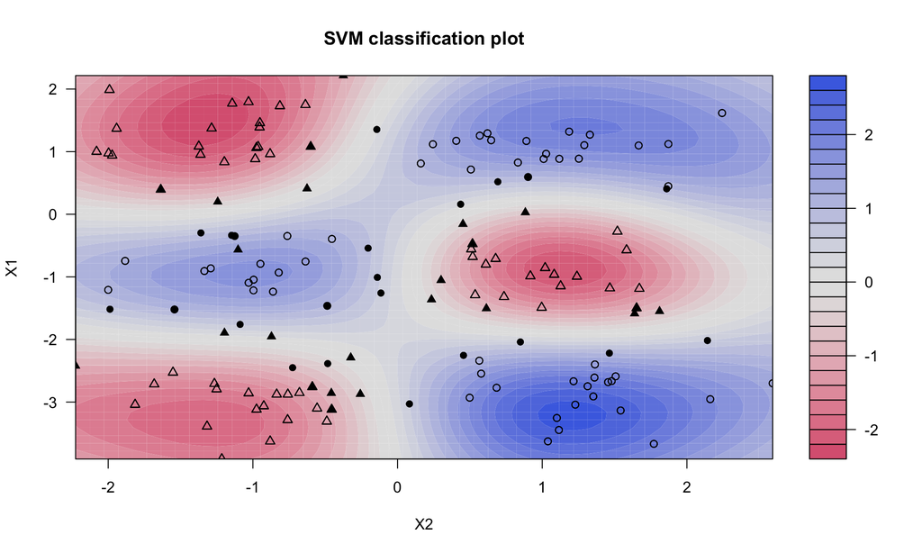